# GO and KEGG Term Enrichment of DE Genes Between DepMap Primary Melanoma and MetMap Aggressive Metastases Samples

### Enrich plots

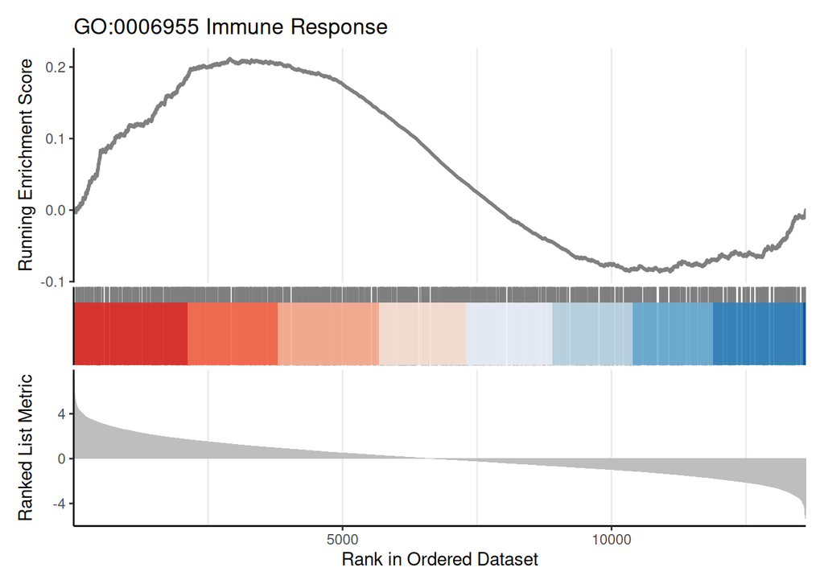

```r
# Enrichment plot for a specific gene set
enrichplot::gseaplot2(gsea_go,
                      geneSetID = "GO:0006955",
                      title = "GO:0006955 Immune Response")
```

## Tables of significant GO and KEGG terms

We filter the GSEA GO and KEGG results to display only the significant terms in interactive tables.

**NOTE: All GO and KEGG terms are still present in the final GSEA Excel result files; only the non-significant terms and pathways are removed here for reasons of space and convenience.**

```r
gsea_go@result %>%
  dplyr::arrange(p.adjust) %>%
  as.data.frame() -> gsea_go_res

gsea_go_res %>%
  dplyr::filter(p.adjust < 0.05) %>%
  dplyr::mutate(enrichmentScore = signif(enrichmentScore, 3),
                NES = signif(NES, 3),
                pvalue = signif(pvalue, 3),
                p.adjust = signif(p.adjust, 3),
                qvalue = signif(qvalue, 3)) %>%
  dplyr::select(-c(rank, leading_edge, core_enrichment)) %>%
  as_tibble() %>%
  DT::datatable()
```

|  | ONTOLOGY | ID | Description | setSize | enrichmentScore | NES | pvalue | p.adjust | qvalue |
| --- | --- | --- | --- | --- | --- | --- | --- | --- | --- |
| 1 | BP | GO:0006261 | DNA-templated DNA replication | 148 | 0.568 | 2.58 | 1e-10 | 2.29e-08 | 2.05e-08 |
| 2 | BP | GO:1905818 | regulation of chromosome separation | 71 | 0.632 | 2.53 | 1e-10 | 2.29e-08 | 2.05e-08 |
| 3 | BP | GO:0007088 | regulation of mitotic nuclear division | 107 | 0.58 | 2.5 | 1e-10 | 2.29e-08 | 2.05e-08 |
| 4 | BP | GO:0000070 | mitotic sister chromatid segregation | 182 | 0.537 | 2.5 | 1e-10 | 2.29e-08 | 2.05e-08 |
| 5 | BP | GO:0140014 | mitotic nuclear division | 258 | 0.51 | 2.47 | 1e-10 | 2.29e-08 | 2.05e-08 |
| 6 | BP | GO:0000819 | sister chromatid segregation | 220 | 0.519 | 2.46 | 1e-10 | 2.29e-08 | 2.05e-08 |
| 7 | BP | GO:0007059 | chromosome segregation | 379 | 0.486 | 2.43 | 1e-10 | 2.29e-08 | 2.05e-08 |
| 8 | BP | GO:0051783 | regulation of nuclear division | 122 | 0.553 | 2.43 | 1e-10 | 2.29e-08 | 2.05e-08 |
| 9 | BP | GO:0006260 | DNA replication | 257 | 0.5 | 2.42 | 1e-10 | 2.29e-08 | 2.05e-08 |
| 10 | BP | GO:0090068 | positive regulation of cell cycle process | 217 | 0.504 | 2.39 | 1e-10 | 2.29e-08 | 2.05e-08 |

[output cut: 421 more lines]

```r
gsea_kegg@result %>%
  dplyr::arrange(p.adjust) %>%
  as.data.frame() -> gsea_kegg_res

gsea_kegg_res %>%
  dplyr::filter(p.adjust < 0.05) %>%
  dplyr::mutate(enrichmentScore = signif(enrichmentScore, 3),
                NES = signif(NES, 3),
                pvalue = signif(pvalue, 3),
                p.adjust = signif(p.adjust, 3),
                qvalue = signif(qvalue, 3)) %>%
  dplyr::select(-c(rank, leading_edge, core_enrichment)) %>%
  as_tibble() %>%
  DT::datatable()
```

|  | ID | Description | setSize | enrichmentScore | NES | pvalue | p.adjust | qvalue |
| --- | --- | --- | --- | --- | --- | --- | --- | --- |
| 1 | hsa03040 | Spliceosome | 129 | 0.53 | 2.35 | 1e-10 | 3.43e-08 | 3.07e-08 |
| 2 | hsa03410 | Base excision repair | 44 | 0.701 | 2.51 | 2.35e-10 | 4.04e-08 | 3.62e-08 |
| 3 | hsa03030 | DNA replication | 35 | 0.737 | 2.55 | 6.77e-10 | 7.75e-08 | 6.94e-08 |
| 4 | hsa03460 | Fanconi anemia pathway | 52 | 0.617 | 2.3 | 8.34e-08 | 7.15e-06 | 6.41e-06 |
| 5 | hsa04110 | Cell cycle | 152 | 0.453 | 2.04 | 1.44e-07 | 9.91e-06 | 8.88e-06 |
| 6 | hsa03013 | Nucleocytoplasmic transport | 100 | 0.454 | 1.92 | 1.44e-05 | 0.000823 | 0.000737 |
| 7 | hsa04141 | Protein processing in endoplasmic reticulum | 161 | -0.353 | -1.77 | 2.07e-05 | 0.00101 | 0.000908 |
| 8 | hsa05171 | Coronavirus disease - COVID-19 | 178 | -0.333 | -1.68 | 3.52e-05 | 0.00151 | 0.00135 |
| 9 | hsa03010 | Ribosome | 134 | -0.374 | -1.81 | 4.79e-05 | 0.00183 | 0.00164 |
| 10 | hsa04140 | Autophagy - animal | 158 | -0.332 | -1.65 | 0.000119 | 0.00409 | 0.00367 |

[output cut: 10 more lines]

## Save results

The unfiltered GSEA results are saved as `.rds` and `.xlsx` Excel files containing two sheets corresponding to the GO and KEGG terms from the respective GSEA analyses.

```r
gsea_res <- list(gsea_go_res, gsea_kegg_res)
names(gsea_res) <- c("GO_GSEA_results", "KEGG_GSEA_results")
write_xlsx(x = gsea_res, path = paste0(
  "./results/", project_name, "_GSEA_results_", Sys.Date(), ".xlsx"))
saveRDS(object = gsea_res, file = paste0(
  "./results/", project_name, "_GSEA_results_", Sys.Date(), ".rds"))
```